# agricolaeplotr: A Package for Visualization of Design of Experiments

## full control Positions design

The ‘FielDHub’ package also provides support to create full factorial designs, that can be plotted by the provided functions.

Both plotting functions supports a shift parameter that is tested in the input section.

```r
fullFact <- FielDHub::full_factorial(setfactors = c(2,2,2), reps = 3,
                            l = 1, type = 2,
                            plotNumber = 101,
                            continuous = TRUE,
                            planter = "serpentine",
                            seed = 325,
                            locationNames = "FARGO")

fullFact$infoDesign
```

```
## $factors
## [1] "A" "B" "C"
##
## $levels
## [1] 0 1 0 1 0 1
##
## $runs
## [1] 8
##
## $all_treatments
##   A B C
## 1 0 0 0
## 2 1 0 0
## 3 0 1 0
## 4 1 1 0
## 5 0 0 1
## 6 1 0 1
## 7 0 1 1
## 8 1 1 1
##
## $reps
## [1] 3
##
## $locations
## [1] 1
##
## $location_names
## [1] "FARGO"
##
## $kind
## [1] "RCBD"
##
## $levels_each_factor
## [1] 2 2 2
##
## $id_design
## [1] 4
```

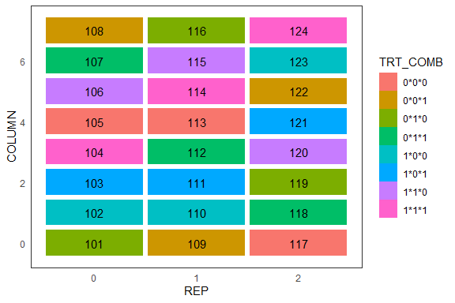

```r
fullFact$fieldBook$COLUMN <-  rep(seq_len(length(unique(fullFact$fieldBook$TRT_COMB))),times=max(fullFact$fieldBook$REP))

full_control_positions(fullFact$fieldBook,x="REP",y="COLUMN",
                       factor_name = "TRT_COMB ",
                       labels="PLOT", shift_x= -1,shift_y = -1)
```

```
## [1] "Your Design ID is supported."
```

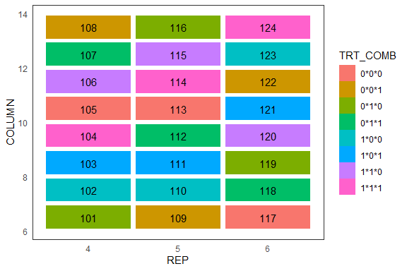

```r
plot_fieldhub(fullFact,x="REP",y="COLUMN",
              factor_name = "TRT_COMB",
              labels="PLOT",shift_x=3,shift_y = 5.5)
```

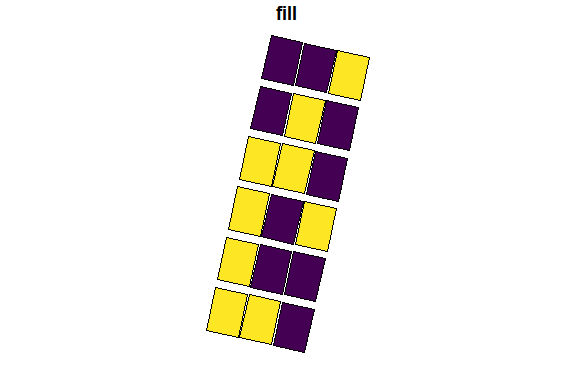

```r
trt<-c(3,2) # factorial 3x2
outdesign <- design.ab(trt, r=3, serie=2,design = 'crd')
plt <- plot_design.factorial_crd(outdesign,ncols=3,nrows=6, width = 5, height = 7.5 , reverse_x = FALSE,reverse_y = TRUE, factor_name = "B") + theme_pres() + scale_fill_viridis_d()

spat_df <- make_polygons(plt,east = 3454206.89,
                         north = 5939183.21 ,
                         projection_output = '+init=EPSG:4326')

plot(spat_df["fill"],col=spat_df$fill)
```

```r
# this part does not work well in a vignette
library(leaflet)

spat_df <- sf:::as_Spatial(spat_df)

spat_df <- sp::elide(spat_df,rotate = -90)

 leaflet(spat_df) %>% addPolygons(
   fillColor = spat_df$fill,
   opacity=1,
   color="black",
   fillOpacity = 1) %>% addProviderTiles(provider = "OpenStreetMap.DE")
```

[interactive chart not shown]

Beginning here, some designs are only partly supported, as there are sometimes no definition from the authors of ‘FielDHub’ how to plot their designs.

#### strip_plot

```r
H <- paste("H", 1:4, sep = "")
V <- paste("V", 1:5, sep = "")

strip1 <- FielDHub::strip_plot(Hplots = H,
                     Vplots = V,
                     b = 1,
                     l = 1,
                     plotNumber = 101,
                     planter = "serpentine",
                     locationNames = "A",
                     seed = 333)

strip1$infoDesign
```

```
## $Hplots
## [1] 4
##
## $Vplots
## [1] 5
##
## $blocks
## [1] 1
##
## $numberLocations
## [1] 1
##
## $nameLocations
## [1] "A"
##
## $seed
## [1] 333
##
## $id_design
## [1] 7
```

```
## [1] "Your Design ID is supported."
```

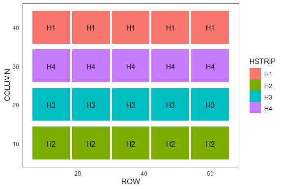

```r
strip1$fieldBook$ROW <- as.numeric(ordered(strip1$fieldBook$VSTRIP, levels = unique(strip1$fieldBook$VSTRIP)))

strip1$fieldBook$COLUMN <- as.numeric(ordered(strip1$fieldBook$HSTRIP, levels = unique(strip1$fieldBook$HSTRIP)))

plot_fieldhub(strip1,
x = "ROW",
y = "COLUMN",
labels = "HSTRIP",
factor_name = "HSTRIP",
width = 12,
height = 10,
reverse_y = FALSE,
reverse_x = FALSE)
```

```
## [1] "Your Design ID is supported."
```

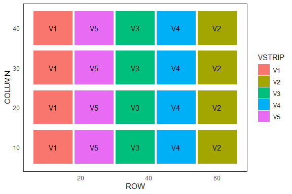

```r
plot_fieldhub(strip1,
x = "ROW",
y = "COLUMN",
labels = "VSTRIP",
factor_name = "VSTRIP",
width = 12,
height = 10,
reverse_y = FALSE,
reverse_x = FALSE)
```

### latin_square design

```r
latinSq1 <- FielDHub::latin_square(t = 4,
                         reps = 2,
                         plotNumber = 101,
                         planter = "cartesian",
                         seed = 1980)

latinSq1$infoDesign
```

```
## $treatments
## [1] 4
##
## $squares
## [1] 2
##
## $locationName
## NULL
##
## $seed
## [1] 1980
##
## $id_design
## [1] 3
```

```
## [1] "Your Design ID is supported."
```

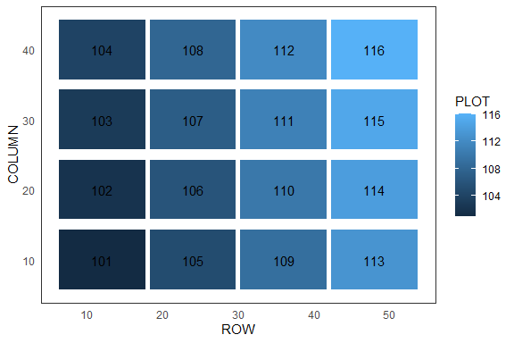

```r
latinSq1$fieldBook$ROW <- as.numeric(ordered(latinSq1$fieldBook$ROW, levels = unique(latinSq1$fieldBook$ROW)))

latinSq1$fieldBook$COLUMN <- as.numeric(ordered(latinSq1$fieldBook$COLUMN, levels = unique(latinSq1$fieldBook$COLUMN)))

# Unitl now: plotting only one replication at a time (here a SQUARE)
latinSq1$fieldBook <- latinSq1$fieldBook[latinSq1$fieldBook$SQUARE==1,]

plot_fieldhub(latinSq1,
x = "ROW",
y = "COLUMN",
labels = "PLOT",
factor_name = "PLOT",
width = 12,
height = 10,
reverse_y = FALSE,
reverse_x = FALSE)
```

#### rowcolum design

```r
rowcold1 <- FielDHub::row_column(t = 36, nrows = 6, r = 3, l = 1,
                       plotNumber= 101,
                       locationNames = "Loc1",
                       seed = 21)

rowcold1$infoDesign
```

```
## $rows
## [1] 6
##
## $columns
## [1] 6
##
## $reps
## [1] 3
##
## $treatments
## [1] 36
##
## $locations
## [1] 1
##
## $location_names
## [1] "Loc1"
##
## $seed
## [1] 21
##
## $id_design
## [1] 9
```

```r
rowcold1$resolvableBlocks
```

```
## $Loc_Loc1
## $Loc_Loc1$rep1
##      [,1] [,2] [,3] [,4] [,5] [,6]
## [1,]   36    5   11   33   29   10
## [2,]   21   28    6   16    9   32
## [3,]   24   30    2   26   18    4
## [4,]   27   20   12    8    3   35
## [5,]   19   34   14   23   17    7
## [6,]   25   22   15    1   13   31
##
## $Loc_Loc1$rep2
##      [,1] [,2] [,3] [,4] [,5] [,6]
## [1,]   26   11   36    5   24    6
## [2,]   17   16    9   33   29   10
## [3,]   31   12    1   27    7   22
## [4,]   21   25   20   32   13   23
## [5,]   14   18   15   30   34    3
## [6,]   28   35    4    2    8   19
##
## $Loc_Loc1$rep3
##      [,1] [,2] [,3] [,4] [,5] [,6]
## [1,]    2   18    5   20   24   27
## [2,]   13   14   35   17   28   26
## [3,]   31   19   23    8    4    9
## [4,]   22    7   29   25    3   34
## [5,]   36   30   15   32   33   11
## [6,]   16    1   21    6   12   10
```

```
## [1] "Your Design ID is supported."
```

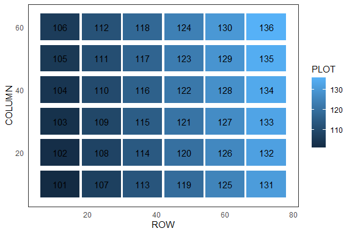

```r
# Unitl now: plotting only one replication
rowcold1$fieldBook <- rowcold1$fieldBook[rowcold1$fieldBook$REP==1,]


plot_fieldhub(rowcold1,
x = "ROW",
y = "COLUMN",
labels = "PLOT",
factor_name = "PLOT",
width = 12,
height = 10,
reverse_y = FALSE,
reverse_x = FALSE)
```

#### rcbd design # (only for serpentine)

```r
rcbd1 <- FielDHub::RCBD(t = LETTERS[1:20], reps = 5, l = 3,
              plotNumber = c(101,1001, 2001),
              continuous = TRUE,
              planter = "serpentine",
              seed = 1020,
              locationNames = c("FARGO", "MINOT", "CASSELTON"))
rcbd1$infoDesign
```

```
## $blocks
## [1] 5
##
## $number.of.treatments
## [1] 20
##
## $treatments
##  [1] "A" "B" "C" "D" "E" "F" "G" "H" "I" "J" "K" "L" "M" "N" "O" "P" "Q" "R" "S"
## [20] "T"
##
## $locations
## [1] 3
##
## $plotNumber
##  [1]  101  201  301  401  501 1001 1101 1201 1301 1401 2001 2101 2201 2301 2401
##
## $locationNames
## [1] "FARGO"     "MINOT"     "CASSELTON"
##
## $seed
## [1] 1020
##
## $id_design
## [1] 2
```

```
## [1] "Your Design ID is supported."
```

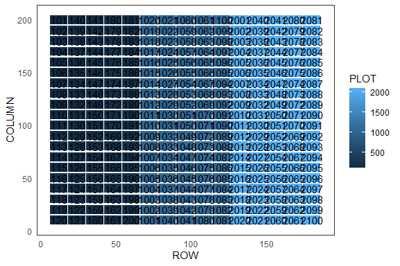

```r
rcbd1$fieldBook$ROW <- rep(1:15,each=20)
rcbd1$fieldBook$COLUMN <- serpentine(n=20,times = 15)

plot_fieldhub(rcbd1,
x = "ROW",
y = "COLUMN",
labels = "PLOT",
factor_name = "PLOT",
width = 12,
height = 10,
reverse_y = TRUE,
reverse_x = FALSE)
```

```r
rcbd1 <- FielDHub::RCBD(t = LETTERS[1:20], reps = 5, l = 3,
              plotNumber = c(101,1001, 2001),
              continuous = TRUE,
              planter = "cartesian",
              seed = 1020,
              locationNames = c("FARGO", "MINOT", "CASSELTON"))

rcbd1$infoDesign
```

```
## $blocks
## [1] 5
##
## $number.of.treatments
## [1] 20
##
## $treatments
##  [1] "A" "B" "C" "D" "E" "F" "G" "H" "I" "J" "K" "L" "M" "N" "O" "P" "Q" "R" "S"
## [20] "T"
##
## $locations
## [1] 3
##
## $plotNumber
##  [1]  101  201  301  401  501 1001 1101 1201 1301 1401 2001 2101 2201 2301 2401
##
## $locationNames
## [1] "FARGO"     "MINOT"     "CASSELTON"
##
## $seed
## [1] 1020
##
## $id_design
## [1] 2
```

```
## [1] "Your Design ID is supported."
```

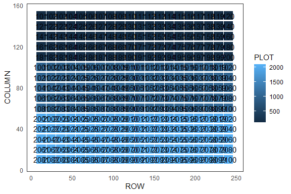

```r
rcbd1$fieldBook$ROW <- rep(1:20,times=15)
rcbd1$fieldBook$COLUMN <- rep(1:15,each=20)

plot_fieldhub(rcbd1,
x = "ROW",
y = "COLUMN",
labels = "PLOT",
factor_name = "PLOT",
width = 12,
height = 10,
reverse_y = TRUE,
reverse_x = FALSE)
```

# Output of central properties of a design of experiment

The user can choose some outputs to have deeper insights of the experiment.

1. The net plot is more or less the actually used plot, without the borders on a plot level.
2. The gross plot is the sum of the net plot and the border of a plot.
3. The sum of all gross plots with the respective space in between is named the field.
4. The experiment shows some properties that are unrelated to the plots on a field.
5. The user also can choose the combined output listed from the elements by typing part = ‘all’.

The DOE_obj function uses the ggplot object and extract relevant field information. This is required, as the summary cannot use the ggplot object. The user also my use a different unit than meter (default).

The user may extract the actual values, as they are separated from the descriptors using normal data.frame related command and operations.

```r
varieties<-c('perricholi','yungay','maria bonita','tomasa')
outdesign <-design.youden(varieties,r=2,serie=2,seed=23)
p <- plot_youden(outdesign, labels = 'varieties', width=4, height=3)
stats <- DOE_obj(p)
r <- to_table(stats,part = "net_plot", digits = 2)
r
```

```
##                        names vals
## 1         net plot height: m 2.60
## 2          net plot width: m 3.80
## 3       net plot diagonal: m 4.60
## 4         net plot area: m^2 9.70
## 5      share used plot area: 0.81
## 6 share space between plots: 0.19
## 7             space_width: m 0.45
## 8            space_height: m 0.20
```

```r
r <- to_table(stats,part = "gross_plot", digits = 2)
r
```

```
##                              names  vals
## 1             gross plot height: m  3.00
## 2              gross plot width: m  4.00
## 3           gross plot diagonal: m  5.00
## 4             gross plot area: m^2 12.00
## 5            gross space area: m^2 18.00
## 6      share used plot area: %/100  0.81
## 7 share space between plots: %/100  0.19
## 8                   space_width: m  0.45
## 9                  space_height: m  0.20
```

```r
r <- to_table(stats,part = "field", digits = 2)
r
```

```
##                        names  vals
## 1    relative design height:  0.85
## 2     relative design width:  0.95
## 3 net experiment diagonal: m 11.00
## 4    net experiment width: m  7.80
## 5   net experiment height: m 12.00
## 6        used plot area: m^2 78.00
## 7         used area DOE: m^2 90.00
## 8       used outer area: m^2 96.00
## 9    outer field diagonal: m 14.00
```

```r
r <- to_table(stats,part = "experiment", digits = 2)
r
```

```
##                names vals
## 1              xmin:  2.1
## 2              xmax:  9.9
## 3              ymin:  1.7
## 4              ymax: 13.0
## 5    number columns:  2.0
## 6       number rows:  4.0
## 7   number of plots:  8.0
## 8 number of factors:  4.0
```

```r
r <- to_table(stats,part = "all", digits = 2)
r
```

```
##                         names  vals
## 1          net plot height: m  2.60
## 2           net plot width: m  3.80
## 3        net plot diagonal: m  4.60
## 4          net plot area: m^2  9.70
## 5       share used plot area:  0.81
## 6  share space between plots:  0.19
## 7              space_width: m  0.45
## 8             space_height: m  0.20
## 9        gross plot height: m  3.00
## 10        gross plot width: m  4.00
## 11     gross plot diagonal: m  5.00
## 12       gross plot area: m^2 12.00
## 13      gross space area: m^2 18.00
## 14    relative design height:  0.85
```

[output cut: 16 more lines]

# full command of a plot

Sometime it it useful to use same plotting function with a known behaviour for plotting purposes. the user may choose the origin (0|0) being in the lower left corner of the net plot. The field design needs to be a data.frame, and not a list like usually used in ‘agricolae’.

```r
varieties<-c('perricholi','yungay','maria bonita','tomasa')
outdesign <-design.youden(varieties,r=2,serie=2,seed=23)
design <- outdesign$book
design
```

```
##   plots row col    varieties
## 1   101   1   1 maria bonita
## 2   102   1   2       tomasa
## 3   201   2   1   perricholi
## 4   202   2   2       yungay
## 5   301   3   1       yungay
## 6   302   3   2 maria bonita
## 7   401   4   1       tomasa
## 8   402   4   2   perricholi
```

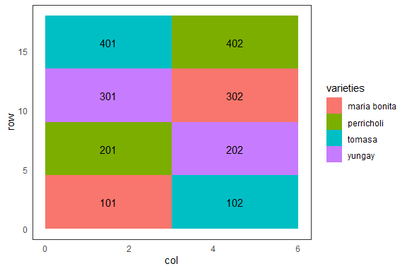

```r
p <- full_control_positions(design,"col","row","varieties","plots",
                       width=3,height=4.5,
                       space_width=1,space_height=1,
                       shift_x=-0.5*3,shift_y=-0.5*4.5)
p
```

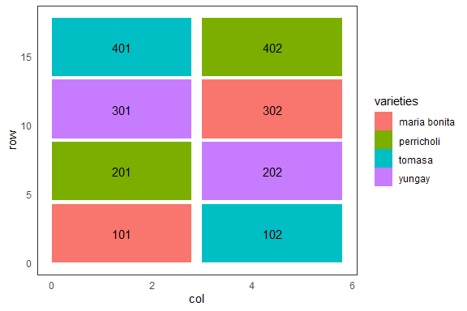

```r
p <- full_control_positions(design,"col","row","varieties","plots",
                       width=3,height=4.5,
                       space_width=0.93,space_height=0.945,
                       start_origin = TRUE)
                       p
```

## complete ramdomized designs

```r
crd1 <- FielDHub::CRD(t = 10,
            reps = 5,
            plotNumber = 101,
            seed = 1987,
            locationName = "Fargo")
crd1$infoDesign
```

```
## $numberofTreatments
## [1] 10
##
## $treatments
##  [1] "T1"  "T2"  "T3"  "T4"  "T5"  "T6"  "T7"  "T8"  "T9"  "T10"
##
## $Reps
## [1] 5
##
## $locationName
## [1] "Fargo"
##
## $seed
## [1] 1987
##
## $id_design
## [1] 1
```

```
## [1] "Your Design ID is supported."
```

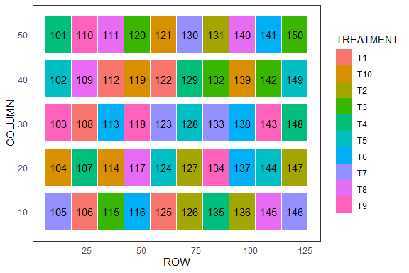

```r
crd1$fieldBook$ROW <- rep(1:10,each=5)
crd1$fieldBook$COLUMN <- serpentine(n=5,times = 10)

plot_fieldhub(crd1,
x = "ROW",
y = "COLUMN",
labels = "PLOT",
factor_name = "TREATMENT",
width = 12,
height = 10,
reverse_y = TRUE,
reverse_x = FALSE)
```

# Scholar related functions

In science it is common to cite used R-packages as the authors put in a lot of effort, time and money to program and maintaining them. As the citations are the actual currency, the citation function should be run at the bottom off an R script.

```r
citation("agricolaeplotr")
```

```
##
##   Jens Harbers, (2023). agricolaeplotr:A Package for Visualization of
##   Design of Experiments
##   https://CRAN.R-project.org/package=agricolaeplotr
##
## Ein BibTeX-Eintrag für LaTeX-Benutzer ist
##
##   @Manual{,
##     title = {{agricolaeplotr}: A Package for Visualization of Design of Experiments},
##     author = {Jens Harbers},
##     year = {2023},
##     url = {https://CRAN.R-project.org/package=agricolaeplotr},
##   }
```